# Operating Characteristics of the Tier-2 De-biased Gate

Estimation/coverage head-to-head against the Tier-1 bootstrap, on the León (2024) Table 2 design

Author

Larry León

Published

July 23, 2026

> **Status — smoke test.** This is the development configuration of the simulation: tiny counts to wire the pipeline end-to-end on a single M1 cell before scaling up. Every tunable lives in the setup chunk (Section 2); the counts (`n_sims`, `nb_boots`, `gate_draws`) are the main knobs for moving from smoke test to production; `run_mode` and `sim_id_start` (Section 2) split a long run into seed-disjoint batches that combine later. Each batch render persists its results to an `.rds`; `run_mode = "combine"` reads them back and renders every table on the pooled set.

# 1 What this evaluates

The **Tier-2 de-biased gate** (`fs_debias_gate()`, surfaced through `forestsearch(debias_gate = TRUE)`) is a refit-free multiplier-bootstrap approximation of León’s post-selection bias correction, with an infinitesimal-jackknife (IJ) confidence interval. To first order its point estimate equals León’s Eq. 7 correction and its interval equals León’s IJ variance, the only approximation being the per-subgroup `dfbeta` linearization.

This document turns the single-trial validation into operating characteristics by re-running the León (2024) estimation/coverage design and recording, **per replicate on the same data and the same selected subgroup**:

- **oracle** $\hat\theta(H)$ — refit on the *true* harm subgroup;
- **naive** $\hat\theta(\hat H)$ — plugin on the identified subgroup;
- **Tier-1** $\hat\theta^{*}(\hat H)$ — full nonparametric bootstrap bias-correction (`forestsearch_bootstrap_dofuture()`, León Eq. 7, the `H2` variant accounting for both bias sources) with its IJ interval;
- **Tier-2** $\tilde\theta(\hat H)$ — the de-biased gate with its IJ interval.

# 2 Setup — all knobs

```r
.t0_doc <- Sys.time()    # start of document-level wall-clock (total reported at the very end)

# NOTE: forestsearch must be INSTALLED (devtools::install()), not load_all():
# the doFuture multisession workers spawn separate R processes that only see the
# installed package.
library(forestsearch)
library(survival)
library(data.table)
library(gt)
library(ggplot2)
library(foreach)
library(doFuture)
library(future)

# Single-source bundle enrichment: beta(Hhat)/beta(Hhat^c) truth targets at the
# realized region, plus covariate-name extraction for the identification figures.
# Must sit in the render working directory.  rule_covs() ships to the %dofuture%
# workers as a detected global of record_replicate (as .na_record/.classify do).
source("betaHhat_truth.R")

# Parallelization topology (works with run_mode / batching above):
#   "sims"  -> replicates fan out across workers; each replicate's forestsearch +
#              bootstrap run sequentially.  Best when n_sims >= n_workers (fills cores).
#   "boots" -> replicates run sequentially; the forestsearch search AND the nb_boots
#              bootstrap fan out across workers WITHIN each replicate.  Best when
#              n_sims is small (single-/few-trial deep dives) and "sims" would idle cores.
# Bootstrap resample indices are seeded on the main process, so results are
# plan-invariant: the two modes differ in WALL-CLOCK only, not in detection/estimates.
parallel_mode <- "boots"

# ── Smoke-test counts (the only knobs to change for production) ────────────
n_sims       <- 480L      # simulated trials                (prod: 1000 -> 20000)
diag_mode    <- FALSE     # DIAGNOSTIC: TRUE caps the run to 5 replicates and relays each
                          # worker's forestsearch() error (otherwise swallowed by the inner
                          # tryCatch).  Set FALSE for a real run.
nb_boots     <- 300L      # Tier-1 nonparametric bootstraps (prod: 200 -> 500).
                          # Set 0L (or NULL) to SKIP Tier-1 entirely and run only
k_random_noise <- 0       # Add k_random_noise confounders

# ── Batching across renders (split one long run into seed-disjoint pieces) ──
# Each render is ONE batch of `n_sims` replicates starting at `sim_id_start`.
# Every per-replicate seed is `seed_base + sim_id` (DGM, search, bootstrap, AND
# the noise covariates), so disjoint sim_id ranges across renders are independent
# and pool to exactly what one big run would have produced:
#
#   Batch 1 : run_mode "batch", sim_id_start = 1     -> ..._res_1_100.rds
#   Batch 2 : run_mode "batch", sim_id_start = 101   -> ..._res_101_200.rds   (re-render)
#   ...      (re-render per batch, advancing sim_id_start by n_sims each time)
#   Combine : run_mode "combine"                     -> reads ..._res_*.rds, rbinds,
#                                                       renders every table on the union
#
# DEFAULT is a single batch starting at 1: render once and you have the whole run.
run_mode     <- "combine"   # "batch" (run + save one piece) | "combine" (merge + report)
sim_id_start <- 21L        # first sim_id of THIS batch (101L, 201L, ... for later pieces)

subgroup_method <- "dina"  # "consistency" | "dina" | "grf"

target_hr_harm  <- 1.0    # calibrate k_inter to this Cox HR in the harm subgroup
n_sample        <- 500L   # M1 sample size

# Output stem derives from the knobs above, so changing n_sample / target_hr_harm /
# k_random_noise / subgroup_method renames every saved file automatically -- no manual
# edit, and DINA/GRF runs never overwrite the consistency files. The leading token IS
# the subgroup method: "fs" for consistency (back-compatible -- the consistency stem is
# unchanged), else "dina"/"grf". Batch range is appended below.
method_tag   <- if (identical(subgroup_method, "consistency")) "fs" else subgroup_method
rds_stem     <- sprintf("%s_t1_t2_m1_h%02d_knoise%d_n%d",
                        method_tag, round(10 * target_hr_harm), k_random_noise, n_sample)

sim_id_end   <- sim_id_start + n_sims - 1L
rds_path     <- sprintf("%s_res_%d_%d.rds", rds_stem, sim_id_start, sim_id_end)  # THIS batch's file
combine_glob <- sprintf("%s_res_*.rds", rds_stem)   # combine mode: which batch files to merge
combine_files <- NULL   # optional explicit character vector; NULL -> use combine_glob
save_combined <- TRUE   # combine mode: ALSO write the pooled bundle to disk
combined_path <- NULL   # NULL -> auto "<rds_stem>_combined_<min>_<max>.rds" (deliberately
                        # outside combine_glob, so a re-combine never re-ingests the pool)

# ── Persist results? The Tier-1 bootstrap (B x n_sims, each re-running the
# engine) is the wall-clock bottleneck; saving the results bundle lets you
# regenerate the summary tables without re-running the simulation.

# Scale-up scenarios for the timing projection (n_sims, nb_boots). Edit freely.
proj_scenarios <- list(
  c(n_sims = 100L,  nb_boots = 300L),
  c(n_sims = 500L,  nb_boots = 300L),
  c(n_sims = 10000L, nb_boots = 500L)
)
                          # the Tier-2 gate -- see run_tier1 below.
gate_draws   <- 5000L     # Tier-2 multiplier draws         (keep ~2000)

save_rds <- identical(run_mode, "batch") && !is.null(rds_path)  # write only when running a batch

# Tier-1 is the wall-clock bottleneck.  forestsearch_bootstrap_dofuture() itself
# requires nb_boots >= 1 (it errors otherwise), so a skip is enforced HERE -- the
# bootstrap is simply never called -- rather than by passing 0L/NULL into it.
# nb_boots = 0L (or NULL) => run_tier1 = FALSE => Tier-2-only run.
run_tier1 <- is.numeric(nb_boots) && length(nb_boots) == 1L && nb_boots >= 1L
run_smoke    <- TRUE      # master flag; FALSE short-circuits the run loop


# ── DGM: León M1 cell (GBSG AFT super-population, alt hypothesis) ───────────
dgm_model       <- "alt"
analysis_time   <- 84     # administrative censoring (months)
cens_adjust     <- log(1.5)
n_super         <- 100000L  # fixed super-population = the eligible-patient universe; trials AND beta(Hhat) draw from this one pool

# ── Subgroup-identification method ─────────────────────────────────────────
# The Tier-1 bootstrap (H2, León Eq.7) re-runs whichever engine fs.est used,
# regenerating the candidate family on each resample, so the Tier-1-vs-Tier-2
# comparison is produced for every engine.  Interpretation differs by engine:
# for "consistency" the family is fixed, so Tier-1 and the gate target the same
# estimand and should agree (the dfbeta-linearisation check); for "dina"/"grf"
# the family regenerates per resample, so Tier-1 is the *unconditional*
# comparator against the gate's *conditional-on-family* estimate, and a
# Tier-1<->Tier-2 gap is the family-regeneration signal, not an error.

grf_selection   <- "frontier"      # only if subgroup_method == "grf": "tree" | "frontier"
grf_select_statistic <- "effect"   # only if grf frontier: "dr" | "effect" (no-op for tree)
grf_depth       <- 2L              # GRF policy-tree depth / max frontier conjunctions
dmin.grf        <- 0.0             # GRF DR-score screening floor
dina_args       <- list()          # extra args forwarded to the DINA selector (dina_args =)
dina_select_statistic <- "effect"  # only if subgroup_method == "dina": "dina" | "effect"

# ── Search configuration (León tuning; resample identification) ────────────
consistency_method <- "resample"   # decided: resample identification (the new default)
sg_focus           <- "eff"        # -> "hr": highest consistency rate, ties by effect
# Gate re-selection is no longer set explicitly: forestsearch() derives it from
# sg_focus (consistency + "eff" -> "maxcons"), reproducing the legacy explicit
# value while staying faithful per engine.  Override via `reselection =` in
# debias_gate_args (advanced use only).
selection_rule     <- "neighborhood"  # *MaxSG/*MinSG band rule (inert for sg_focus = "eff")
hr_threshold       <- 0.90
hr_consistency     <- 0.80
pconsistency       <- 0.90
fs_splits          <- 400L         # moot under "resample" (closed-form, not literal split)
maxk               <- 2L
n_min              <- NULL
d0_min             <- 10L
d1_min             <- 10L
use_lasso          <- FALSE
use_dina           <- FALSE
use_grf            <- FALSE         # FALSE = LASSO-only (fast, "FSl"); set TRUE for "FSlg"
use_twostage       <- TRUE

fs_conf_force      <- c("meno == 0", "er <= 0", "pgr <= 0")   # premenopausal (raw analog of z3 == 1)
fs_conf.cont_jcuts <- list(er = 10)     # J-quantile grid on raw ER (analog of z1; now meaningful, ER is continuous)

# ── Column names emitted by simulate_from_dgm() ────────────────────────────
outcome_name   <- "y_sim"
event_name     <- "event_sim"
treat_name     <- "treat_sim"
id_name        <- "id"
harm_col       <- "flag_harm"
# Raw GBSG covariate candidates (as in a real analysis): forestsearch discovers
# its own cuts. Continuous -> er, age, pgr, nodes, size; categorical -> meno (0/1),
# grade (1/2/3). The pre-dichotomized z1..z5 are NOT used. The true harm subgroup
# (er <= 25th pct & meno == 0) must be re-discovered from these raw variables.

confounders_base <- c("er", "age", "meno", "pgr", "nodes", "size", "grade")

# ── Reproducibility / parallelism ──────────────────────────────────────────
seed_base  <- 8316951L
n_workers  <- ceiling(0.90*max(1L, min(parallel::detectCores(logical = FALSE) - 1L)))

stopifnot(parallel_mode %in% c("sims", "boots"))
inner_parallel <- if (identical(parallel_mode, "boots"))
  list(plan = "multisession", workers = n_workers) else list(plan = "sequential")
cat(sprintf("Parallel mode: %s (%s)\n", parallel_mode,
            if (identical(parallel_mode, "boots")) "replicates sequential, bootstrap parallel"
            else "replicates parallel, bootstrap sequential"))
```

```
Parallel mode: boots (replicates sequential, bootstrap parallel)
```

```r
z975       <- qnorm(0.975)

cat(sprintf("Smoke test: method=%s%s, n_sims=%d, nb_boots=%s, gate_draws=%d, workers=%d\n",
            subgroup_method,
            if (identical(subgroup_method, "grf")) paste0("/", grf_selection) else "",
            n_sims, if (is.null(nb_boots)) "0 (skip)" else as.character(nb_boots),
            gate_draws, n_workers))
```

```
Smoke test: method=dina, n_sims=480, nb_boots=300, gate_draws=5000, workers=115
```

# 3 Build the DGM and read off the truth targets

```r
`%||%` <- function(a, b) if (is.null(a) || length(a) == 0 || all(is.na(a))) b else a

if (identical(run_mode, "batch")) {
  k_inter <- calibrate_k_inter(target_hr_harm = target_hr_harm,
                               model = dgm_model, use_ahr = FALSE)

  dgm <- setup_gbsg_dgm(model = dgm_model, k_inter = k_inter,
                        n_super = n_super, seed = seed_base)
  dgm <- compute_dgm_cde(dgm)   # attaches CDE (theta-ddagger) targets

  # Fixed (population) truth targets, read defensively from the DGM object.
  truth <- list(
    hr_causal   = dgm$hr_causal   %||% NA_real_,                 # overall causal HR
    marg_H      = dgm$hr_H_true   %||% NA_real_,                 # theta-dagger (H)
    marg_Hc     = dgm$hr_Hc_true  %||% NA_real_,                 # theta-dagger (Hc)
    cde_H       = dgm$cde_H       %||% (dgm$hazard_ratios$CDE_harm    %||% NA_real_),  # theta-ddagger (H)
    cde_Hc      = dgm$cde_Hc      %||% (dgm$hazard_ratios$CDE_no_harm %||% NA_real_)   # theta-ddagger (Hc)
  )

  cat("DGM truth targets (population):\n")
  cat(sprintf("  overall causal HR      : %.3f\n", truth$hr_causal))
  cat(sprintf("  theta-dagger  H / Hc   : %.3f / %.3f\n", truth$marg_H, truth$marg_Hc))
  cat(sprintf("  theta-ddagger H / Hc   : %.3f / %.3f\n", truth$cde_H,  truth$cde_Hc))

  # Conditional target beta(Hhat) is evaluated on the ENTIRE super-population
  # (every dgm$df_super subject once) -- the SAME fixed universe the trials
  # sub-sample -- under the trials' randomized, censored analysis.  beta(Hhat) is
  # n-invariant (a property of the realized rule and the population).  The sanity
  # gate recomputes theta-dagger on this same frame at the true harm flag; it
  # should reproduce dgm$hr_H_true / hr_Hc_true, confirming "population" reads.
  eval_df <- build_eval_frame(dgm, analysis_time = analysis_time,
                              cens_adjust = cens_adjust, eval_seed = 20260628L)
  .td_chk <- betaHhat_theta_dagger_check(eval_df, harm.name = harm_col,
                                         outcome.name = outcome_name,
                                         event.name = event_name, treat.name = treat_name)
  cat(sprintf("  beta(Hhat) eval frame  : n=%d (FULL super-population, each subject once; eval_seed = 20260628)\n", nrow(eval_df)))
  cat(sprintf("  theta-dagger (on frame): %.3f / %.3f  (cross-check vs above)\n",
              .td_chk[["thetaDagger_H"]], .td_chk[["thetaDagger_Hc"]]))
} else {
  # combine mode: the DGM is not needed here; truth is read from the batch
  # bundles in the combine step below.
  truth <- NULL
  cat("Combine mode: DGM build skipped (truth read from batch files).\n")
}
```

```
Combine mode: DGM build skipped (truth read from batch files).
```

# 4 Per-replicate paired recorder

For each simulated trial: identify $\hat H$ and obtain the naive + Tier-2 gate in one `forestsearch()` call, run the Tier-1 bootstrap on the *same* fit (inheriting `consistency_method = "resample"`), and refit the oracle on the true subgroup. Inner `forestsearch()`/bootstrap parallelism follows `parallel_mode` (Section 2): in `"sims"` mode it is sequential because the outer loop parallelises across trials; in `"boots"` mode the outer loop is sequential and the search + bootstrap parallelise across workers within each trial. Results are identical either way.

```r
# Cox HR + delta-method 95% CI on a subset (for the per-replicate oracle).
# Guards against separation: non-finite coef/SE (the "coefficient may be
# infinite" case) returns a clean NA triple rather than Inf/NaN bounds.
.cox_hr_ci <- function(df) {
  if (sum(df[[event_name]]) < 5L || length(unique(df[[treat_name]])) < 2L)
    return(c(est = NA_real_, lo = NA_real_, hi = NA_real_, se = NA_real_))
  fml <- stats::as.formula(
    sprintf("survival::Surv(%s, %s) ~ %s", outcome_name, event_name, treat_name))
  fit <- tryCatch(survival::coxph(fml, data = df), error = function(e) NULL)
  if (is.null(fit)) return(c(est = NA_real_, lo = NA_real_, hi = NA_real_, se = NA_real_))
  b  <- unname(stats::coef(fit)[1])
  v  <- unname(suppressWarnings(diag(stats::vcov(fit))[1]))  # unname: else lo/hi inherit coef name -> oH["lo"] = NA
  se <- if (is.finite(v) && v > 0) sqrt(v) else NA_real_
  if (!is.finite(b) || !is.finite(se))
    return(c(est = NA_real_, lo = NA_real_, hi = NA_real_, se = NA_real_))
  c(est = exp(b), lo = exp(b - z975 * se), hi = exp(b + z975 * se), se = se)
}

# Recover the log-HR (beta-scale) SE from an HR-scale SD: sd_hr = HR * se_beta,
# so se_beta = sd_hr / HR.  Used for the FB row, whose bootstrap summary reports
# sdH2 on the HR scale.  Returns NA on a non-positive/non-finite estimate.
.se_beta_hr <- function(sd_hr, hr) {
  if (is.finite(sd_hr) && is.finite(hr) && hr > 0) sd_hr / hr else NA_real_
}

# Classification of the identified subgroup against the true harm flag.
# sg_hat is grp.consistency$sg.harm.id: a per-subject 0/1 vector, length
# nrow(df), aligned to the input rows (clean on the consistency result; the
# GRF-object naming collision does not apply here).
.classify <- function(sg_hat, truth) {
  out <- c(sens = NA_real_, spec = NA_real_, ppv = NA_real_, npv = NA_real_)
  if (is.null(sg_hat) || length(sg_hat) != length(truth)) return(out)
  sg_hat <- as.integer(sg_hat); truth <- as.integer(truth)
  tp <- sum(sg_hat == 1 & truth == 1); fp <- sum(sg_hat == 1 & truth == 0)
  fn <- sum(sg_hat == 0 & truth == 1); tn <- sum(sg_hat == 0 & truth == 0)
  out["sens"] <- if (tp + fn > 0) tp / (tp + fn) else NA_real_
  out["spec"] <- if (tn + fp > 0) tn / (tn + fp) else NA_real_
  out["ppv"]  <- if (tp + fp > 0) tp / (tp + fp) else NA_real_
  out["npv"]  <- if (tn + fn > 0) tn / (tn + fn) else NA_real_
  out
}

# One all-NA record (returned on failure so the loop never aborts a cell).
.na_record <- function(sim_id) data.frame(
  sim_id = sim_id, detected = 0L, gate_ok = 0L, n_sel = NA_integer_,
  n_harm = NA_integer_, n_true = NA_integer_,
  label = NA_character_, sg_def = NA_character_, covs = NA_character_,
  betaHhat_H = NA_real_, betaHhat_Hc = NA_real_,
  t1_secs = NA_real_, t2_secs = NA_real_, t1_err = NA_character_,
  or_H_est = NA, or_H_lo = NA, or_H_hi = NA, or_H_se = NA,
  or_Hc_est = NA, or_Hc_lo = NA, or_Hc_hi = NA, or_Hc_se = NA,
  nv_H_est = NA, nv_H_lo = NA, nv_H_hi = NA, nv_H_se = NA,
  nv_Hc_est = NA, nv_Hc_lo = NA, nv_Hc_hi = NA, nv_Hc_se = NA,
  t1_H_est = NA, t1_H_lo = NA, t1_H_hi = NA, t1_H_se = NA,
  t1_Hc_est = NA, t1_Hc_lo = NA, t1_Hc_hi = NA, t1_Hc_se = NA,
  t2_H_est = NA, t2_H_lo = NA, t2_H_hi = NA, t2_H_se_ij = NA,
  t2_Hc_est = NA, t2_Hc_lo = NA, t2_Hc_hi = NA, t2_Hc_se_ij = NA,
  t2_harm_flag = NA_integer_, ij_source = NA_character_,
  sens = NA_real_, spec = NA_real_, ppv = NA_real_, npv = NA_real_,
  stringsAsFactors = FALSE)

record_replicate <- function(sim_id) {
  rec <- .na_record(sim_id)

  df <- tryCatch(
    simulate_from_dgm(dgm, n = n_sample, analysis_time = analysis_time,
                      cens_adjust = cens_adjust, seed = seed_base + sim_id),
    error = function(e) NULL)
  if (is.null(df)) return(rec)
  df[[id_name]] <- seq_len(nrow(df))

  confs <- intersect(confounders_base, names(df))

# Add k_random_noise standard-normal noise covariates
# (k_random_noise is set upstream, e.g. in the setup chunk; 0 = no noise)
if (k_random_noise > 0) {
  noise_names <- paste0("noise", seq_len(k_random_noise))
  # Seed the noise draws by sim_id (offset to stay disjoint from the DGM seed
  # seed_base + sim_id) so the FULL replicate -- survival data AND noise -- is a
  # deterministic function of sim_id, independent of batch and loop position.
  # Without this the noise would draw from future's per-iteration RNG stream,
  # which is keyed to loop position, not sim_id, and could collide across batches.
  set.seed(seed_base + sim_id + 1000000L)
  for (nm in noise_names) {
    df[[nm]] <- rnorm(n = nrow(df))
  }
  confs <- c(confs, noise_names)
}


  rec$n_true <- sum(df[[harm_col]] == 1L, na.rm = TRUE)   # true |Q| this trial (all reps)


  # ---- Identification + naive + Tier-2 gate (single forestsearch call) -----
  # Args common to every method, plus a method-specific block.  Consistency-only
  # tuning (LASSO/two-stage/forced cuts/maxk) is NOT forwarded to DINA/GRF, which
  # have their own candidate enumeration; all methods search the same confs.
  base_args <- list(
    df.analysis     = df,
    outcome.name    = outcome_name, event.name = event_name,
    treat.name      = treat_name,   id.name    = id_name,
    flag_harm.name  = harm_col,     confounders.name = confs,
    is.RCT          = TRUE,         seedit = seed_base + sim_id,
    quiet           = TRUE,         # suppress the "De-biased gate: ..." cat()
    sg_focus        = sg_focus,
    subgroup_method = subgroup_method,
    hr.threshold    = hr_threshold, hr.consistency = hr_consistency,
    pconsistency.threshold = pconsistency, n.min = n_min,
    selection_rule  = selection_rule,   # governs *MaxSG/*MinSG band (search + gate)
    parallel_args   = inner_parallel,              # parallel_mode: sims->sequential, boots->multisession
    debias_gate     = TRUE,
    debias_gate_args = list(ci_method = "ij", draws = gate_draws,
                            include_complement = TRUE)  # reselection derived from sg_focus
  )
  method_args <- switch(
    subgroup_method,
    consistency = list(
      consistency_method = consistency_method,
      use_lasso = use_lasso, use_grf = use_grf, use_twostage = use_twostage,
      use_dina = use_dina,
      conf_force = fs_conf_force, conf.cont_jcuts = fs_conf.cont_jcuts,
      fs.splits = fs_splits, maxk = maxk, d0.min = d0_min, d1.min = d1_min),
    dina = list(dina_select_statistic = dina_select_statistic,
                dina_args             = dina_args),
    grf  = list(grf_selection = grf_selection, grf_depth = grf_depth,
                dmin.grf = dmin.grf, grf_select_statistic = grf_select_statistic),
    stop("unknown subgroup_method: ", subgroup_method)
  )

  t2_t0 <- proc.time()[3]
  fs.est <- tryCatch(do.call(forestsearch, c(base_args, method_args)),
                     error = function(e) {
                       if (isTRUE(get0("diag_mode", ifnotfound = FALSE)))
                         warning(sprintf("FS-ERR sim %d: %s", sim_id,
                                         conditionMessage(e)), call. = FALSE)
                       NULL
                     })
  rec$t2_secs <- proc.time()[3] - t2_t0
  if (is.null(fs.est)) return(rec)

  # Detection is METHOD-AGNOSTIC (a subgroup was identified), independent of
  # whether the Tier-2 gate produced a CI; gate availability is tracked
  # separately in gate_ok so a gate failure never masks a true detection.
  g     <- fs.est$debias_gate
  found <- !is.null(fs.est$sg.harm)
  rec$detected <- as.integer(found)
  if (found) {
    rec$sg_def <- paste(fs.est$sg.harm, collapse = " & ")          # full rule -> beta(Hhat) scoring
    rec$covs   <- paste(rule_covs(fs.est$sg.harm), collapse = "+")  # variable names -> id figures
  }
  if (!found) return(rec)
  rec$gate_ok <- as.integer(!is.null(g))

  if (!is.null(g)) {
    rec$label <- g$selected_label %||% NA_character_
    rec$n_sel <- g$n_selected      %||% NA_integer_
    rec$t2_harm_flag <- as.integer(isTRUE(g$harm_flag))
    rec$ij_source    <- g$debiased$ij_source %||% NA_character_
    rec$nv_H_est <- g$naive$est;    rec$nv_H_lo <- g$naive$lower;    rec$nv_H_hi <- g$naive$upper;    rec$nv_H_se <- g$debiased$se_wald %||% NA_real_
    rec$t2_H_est <- g$debiased$est; rec$t2_H_lo <- g$debiased$lower; rec$t2_H_hi <- g$debiased$upper
    rec$t2_H_se_ij <- g$debiased$se_ij %||% NA_real_
    if (is.list(g$complement) && !is.null(g$complement$debiased)) {
      rec$nv_Hc_est <- g$complement$naive$est
      rec$nv_Hc_lo  <- g$complement$naive$lower
      rec$nv_Hc_hi  <- g$complement$naive$upper
      rec$nv_Hc_se  <- g$complement$debiased$se_wald %||% NA_real_
      rec$t2_Hc_est <- g$complement$debiased$est
      rec$t2_Hc_lo  <- g$complement$debiased$lower
      rec$t2_Hc_hi  <- g$complement$debiased$upper
      rec$t2_Hc_se_ij <- g$complement$debiased$se_ij %||% NA_real_
    }
  }

  # ---- Classification of Ĥ against the true harm flag ----------------------
  cl <- .classify(fs.est$grp.consistency$sg.harm.id, df[[harm_col]])
  rec$sens <- cl["sens"]; rec$spec <- cl["spec"]
  rec$ppv  <- cl["ppv"];  rec$npv <- cl["npv"]
  rec$n_harm <- sum(fs.est$grp.consistency$sg.harm.id == 1L, na.rm = TRUE)

  # ---- Tier-1 bootstrap (H2 = León Eq.7) -----------------------------------
  # forestsearch_bootstrap_dofuture re-runs whichever engine fs.est used (via
  # fs.est$args_call_all), regenerating the candidate family on each resample.
  # For "consistency" the family is fixed, so Tier-1 and the Tier-2 gate target
  # the same estimand; for "dina"/"grf" the family regenerates per resample, so
  # Tier-1 is the *unconditional* comparator against the gate's
  # *conditional-on-family* estimate -- a Tier-1<->Tier-2 gap there is the
  # family-regeneration signal, not an error.  If an engine cannot return H2 the
  # call falls back to NULL (t1_* stay NA) and the message is captured in t1_err.
  if (run_tier1 && subgroup_method %in% c("consistency", "dina", "grf")) {
    t1_t0 <- proc.time()[3]; t1_err <- NA_character_
    boot <- tryCatch(
      forestsearch_bootstrap_dofuture(
        fs.est, nb_boots = nb_boots, seed = seed_base + sim_id,
        parallel_args = inner_parallel),
      error = function(e) { t1_err <<- conditionMessage(e); NULL })
    rec$t1_secs <- proc.time()[3] - t1_t0
    rec$t1_err  <- t1_err
    if (!is.null(boot) && !is.null(boot$H_estimates)) {
      he <- boot$H_estimates                     # H2 = León Eq.7 (both bias sources)
      # %||% guards a missing H2 column (get_dfRes omits H2 when the 2nd-order
      # bias adjustment is unavailable): a bare NULL assignment would DELETE the
      # column from rec, and the short record is then silently dropped by the
      # run-loop's rbind/.errorhandling = "remove" -> a hidden, non-random loss.
      rec$t1_H_est <- he$H2 %||% NA_real_
      rec$t1_H_lo  <- he$H2_lower %||% NA_real_
      rec$t1_H_hi  <- he$H2_upper %||% NA_real_
      rec$t1_H_se  <- .se_beta_hr(he$sdH2 %||% NA_real_, he$H2 %||% NA_real_)
    }
    if (!is.null(boot) && !is.null(boot$Hc_estimates)) {
      hce <- boot$Hc_estimates
      rec$t1_Hc_est <- hce$H2 %||% NA_real_
      rec$t1_Hc_lo  <- hce$H2_lower %||% NA_real_
      rec$t1_Hc_hi  <- hce$H2_upper %||% NA_real_
      rec$t1_Hc_se  <- .se_beta_hr(hce$sdH2 %||% NA_real_, hce$H2 %||% NA_real_)
    }
  }

  # ---- Oracle: refit on the TRUE harm subgroup of this trial ---------------
  oH  <- .cox_hr_ci(df[df[[harm_col]] == 1, , drop = FALSE])
  oHc <- .cox_hr_ci(df[df[[harm_col]] == 0, , drop = FALSE])
  rec$or_H_est <- oH["est"];   rec$or_H_lo <- oH["lo"];   rec$or_H_hi <- oH["hi"];   rec$or_H_se <- oH["se"]
  rec$or_Hc_est <- oHc["est"]; rec$or_Hc_lo <- oHc["lo"]; rec$or_Hc_hi <- oHc["hi"]; rec$or_Hc_se <- oHc["se"]

  rec
}
```

# 5 Run the simulation

```r
results <- NULL
elapsed <- NA_real_   # combine mode has no wall-clock; NA -> em-dash in the timing table

if (run_smoke && identical(run_mode, "batch")) {
  sim_ids <- sim_id_start:(sim_id_start + n_sims - 1L)
  if (isTRUE(diag_mode)) sim_ids <- utils::head(sim_ids, 5L)  # diag cap (not a combinable batch)

  if (identical(parallel_mode, "sims")) {
    # replicates fan out across workers; each replicate's search + bootstrap are sequential
    plan("sequential"); gc()
    plan("multisession", workers = n_workers)

    t_all <- proc.time()[3]
    results <- foreach(
      s = sim_ids,
      .combine = rbind, .errorhandling = "remove",
      .options.future = list(packages = c("forestsearch", "survival", "data.table"),
                             seed = TRUE)
    ) %dofuture% {
      record_replicate(s)
    }
    elapsed <- proc.time()[3] - t_all

    plan("sequential"); gc()   # release workers between phases
  } else {
    # "boots": replicates run sequentially in the main process; the forestsearch
    # search and the nb_boots bootstrap fan out over n_workers WITHIN each replicate
    # (via inner_parallel).  No outer pool -> no nested parallelism.
    plan("sequential"); gc()
    t_all <- proc.time()[3]
    results <- do.call(rbind, lapply(sim_ids, function(s)
      tryCatch(record_replicate(s), error = function(e) NULL)))   # match "remove" semantics
    elapsed <- proc.time()[3] - t_all
    plan("sequential"); gc()
  }

  # Conditional truth targets beta(Hhat)/beta(Hhat^c) for the realized rule of each
  # detected replicate -- deduplicated over distinct sg_def, computed in the main
  # process so the large eval frame stays in one place (not copied into workers).
  results <- attach_betaHhat(results, eval_df, outcome.name = outcome_name,
                             event.name = event_name, treat.name = treat_name)

  cat(sprintf("Batch sim_id %d-%d: %d/%d detections in %.1f s (%.1f s/replicate).\n",
              min(sim_ids), max(sim_ids),
              sum(results$detected, na.rm = TRUE), length(sim_ids), elapsed,
              elapsed / max(1L, length(sim_ids))))
  if (run_tier1) {
    cat(sprintf("Mean wall-clock: Tier-2 gate %.3f s vs Tier-1 bootstrap %.2f s (B=%d).\n",
                mean(results$t2_secs, na.rm = TRUE),
                mean(results$t1_secs, na.rm = TRUE), nb_boots))

    # Surface any (otherwise-swallowed) Tier-1 bootstrap error(s) on detected reps.
    t1_tried <- sum(results$detected == 1L, na.rm = TRUE)
    t1_fail  <- sum(results$detected == 1L & is.na(results$t1_H_est), na.rm = TRUE)
    if (t1_fail > 0L) {
      cat(sprintf("Tier-1 bootstrap returned no estimate on %d of %d detected replicate(s).\n",
                  t1_fail, t1_tried))
      errs <- unique(stats::na.omit(results$t1_err))
      if (length(errs))
        cat("Distinct Tier-1 error(s):\n", paste0("  - ", errs, collapse = "\n"), "\n", sep = "")
    }
  } else {
    cat(sprintf("Mean wall-clock: Tier-2 gate %.3f s  (Tier-1 skipped: nb_boots = %s).\n",
                mean(results$t2_secs, na.rm = TRUE),
                if (is.null(nb_boots)) "NULL" else as.character(nb_boots)))
  }

  # Persist the results bundle (knob in @sec-setup).  Saved as a list so the
  # truth targets and key counts travel with the per-replicate records, and the
  # tables can be regenerated downstream without re-running the simulation.
  if (isTRUE(save_rds) && !is.null(results)) {
    saveRDS(list(results = results, truth = truth,
                 meta = list(n_sample = n_sample, n_sims = n_sims,
                             nb_boots = nb_boots, gate_draws = gate_draws,
                             subgroup_method = subgroup_method,
                             sim_id_start = sim_id_start, sim_id_end = sim_id_end,
                             seed_base = seed_base, parallel_mode = parallel_mode)),
            rds_path)
    cat(sprintf("Saved batch bundle (%d rows, sim_id %d-%d) to %s\n",
                nrow(results), sim_id_start, sim_id_end, rds_path))
  }

} else if (run_smoke && identical(run_mode, "combine")) {
  # ---- Combine seed-disjoint batches into one pooled results set -----------
  # Reads every ..._res_*.rds (or the explicit `combine_files`), validates that
  # the batches are poolable, refuses on overlapping sim_id, and populates the
  # same globals (`results`, `truth`, `n_sims`, ...) the report chunks consume --
  # so every downstream table renders on the union with no other change.
  files <- if (!is.null(combine_files)) combine_files else Sys.glob(combine_glob)
  files <- files[file.exists(files)]
  if (!length(files))
    stop("combine mode: no batch files found (combine_glob = '", combine_glob, "').")

  bundles <- lapply(files, readRDS)

  # Count-invariant meta MUST agree across batches to pool them.
  .meta_get <- function(b, k) b$meta[[k]] %||% NA
  for (k in c("n_sample", "nb_boots", "gate_draws", "subgroup_method", "seed_base")) {
    vals <- unique(lapply(bundles, .meta_get, k = k))
    if (length(vals) > 1L)
      stop(sprintf("combine mode: batches disagree on meta$%s (%s).",
                   k, paste(unlist(vals), collapse = ", ")))
  }

  # truth must match across batches (same DGM + seed_base); use the first.
  truths <- lapply(bundles, `[[`, "truth")
  if (length(truths) > 1L &&
      !all(vapply(truths[-1], identical, logical(1), truths[[1]])))
    warning("combine mode: truth targets differ across batches; using the first.")
  truth <- truths[[1]]

  # Pool the per-replicate records.
  results <- do.call(rbind, lapply(bundles, `[[`, "results"))

  # Disjointness: a repeated sim_id means the seed ranges overlapped, so the
  # pooled set is NOT independent -- refuse rather than silently double-count.
  dup <- unique(results$sim_id[duplicated(results$sim_id)])
  if (length(dup))
    stop(sprintf("combine mode: %d duplicated sim_id across batches (e.g. %s); seed ranges overlap.",
                 length(dup), paste(utils::head(sort(dup), 5L), collapse = ", ")))

  # Make the report self-describing from the files (not the setup chunk's knobs).
  n_sample        <- bundles[[1]]$meta$n_sample        %||% n_sample
  nb_boots        <- bundles[[1]]$meta$nb_boots        %||% nb_boots
  gate_draws      <- bundles[[1]]$meta$gate_draws      %||% gate_draws
  subgroup_method <- bundles[[1]]$meta$subgroup_method %||% subgroup_method
  run_tier1       <- is.numeric(nb_boots) && length(nb_boots) == 1L && nb_boots >= 1L
  n_sims          <- sum(vapply(bundles,
                                function(b) as.integer(b$meta$n_sims %||% NA_integer_),
                                integer(1)))

  rng <- range(results$sim_id)
  cat(sprintf("Combined %d batch file(s) -> %d rows, sim_id %d-%d (n_sims = %d).\n",
              length(files), nrow(results), rng[1], rng[2], n_sims))
  cat("  files: ", paste(basename(files), collapse = ", "), "\n", sep = "")

  # Persist the pooled bundle so downstream docs load ONE file.  The name is
  # chosen to fall OUTSIDE combine_glob ("..._res_*"), so a later re-combine never
  # re-ingests this pooled file alongside the batch pieces.
  if (isTRUE(save_combined)) {
    cpath <- combined_path %||%
      sprintf("%s_combined_%d_%d.rds", rds_stem, rng[1], rng[2])
    saveRDS(list(results = results, truth = truth,
                 meta = list(n_sample = n_sample, n_sims = n_sims,
                             nb_boots = nb_boots, gate_draws = gate_draws,
                             subgroup_method = subgroup_method,
                             sim_id_start = rng[1], sim_id_end = rng[2],
                             seed_base = bundles[[1]]$meta$seed_base %||% NA_integer_,
                             n_batches = length(files),
                             source_files = basename(files))),
            cpath)
    cat(sprintf("Saved pooled bundle (%d rows, sim_id %d-%d, %d batches) to %s\n",
                nrow(results), rng[1], rng[2], length(files), cpath))
  }
}
```

```
Combined 2 batch file(s) -> 500 rows, sim_id 1-500 (n_sims = 500).
  files: dina_t1_t2_m1_h10_knoise0_n500_res_1_20.rds, dina_t1_t2_m1_h10_knoise0_n500_res_21_500.rds
Saved pooled bundle (500 rows, sim_id 1-500, 2 batches) to dina_t1_t2_m1_h10_knoise0_n500_combined_1_500.rds
```

# 6 Population effect at the true region

```r
# beta(H) and beta(H^c): the population effect at the TRUE harm region.  Combine
# mode skips the DGM build above, so (re)build it here -- every constant is
# already in scope and the eval frame is a deterministic function of them, so
# this reproduces the frame batch mode would have used.
k_inter <- calibrate_k_inter(target_hr_harm = target_hr_harm, model = dgm_model,
                             use_ahr = FALSE)
dgm     <- setup_gbsg_dgm(model = dgm_model, k_inter = k_inter,
                          n_super = n_super, seed = seed_base)
dgm     <- compute_dgm_cde(dgm)
eval_df <- build_eval_frame(dgm, analysis_time = analysis_time,
                            cens_adjust = cens_adjust, eval_seed = 20260628L)

# exp{beta(.)} at the TRUE regions. Same functional as beta(Hhat) -- only the region
# differs -- so the two are comparable on this one evaluation frame.
.bH <- betaHhat_theta_dagger_check(eval_df, harm.name = "flag_harm",
                                   outcome.name = "y_sim", event.name = "event_sim",
                                   treat.name = "treat_sim")
betaH_H  <- unname(.bH[["thetaDagger_H"]])    # name is legacy; the value is exp{beta(H)}
betaH_Hc <- unname(.bH[["thetaDagger_Hc"]])
cat(sprintf("beta(H) = %.6f   beta(H^c) = %.6f\n", betaH_H, betaH_Hc))
```

```
beta(H) = 1.002890   beta(H^c) = 0.628085
```

# 7 Timing and scale-up projection

Tier-2 cost per replicate is essentially fixed (one fit + the multiplier draws, independent of `nb_boots`); Tier-1 cost scales **linearly** with `nb_boots` (it re-runs the whole search once per bootstrap). The projection below uses the measured per-replicate times and assumes Tier-1 runs only on detected replicates. The modelled wall-clock spreads the reps over the workers respecting the integer reps-per-worker ceiling, then a single calibration factor (measured wall / modelled wall on this run) carries this run’s realized overhead into the projections.

```r
if (run_smoke && !is.null(results)) {
  t2_mean  <- mean(results$t2_secs, na.rm = TRUE)              # forestsearch + gate, per rep
  det_rate <- mean(results$detected, na.rm = TRUE)
  # Tier-1 timing only when Tier-1 actually ran; nb_boots may be 0L or NULL.
  boots_disp <- if (run_tier1) as.integer(nb_boots) else 0L
  t1_mean  <- if (run_tier1) mean(results$t1_secs, na.rm = TRUE) else NA_real_
  per_boot <- if (run_tier1 && boots_disp > 0L) t1_mean / boots_disp else NA_real_

  fmt_hm <- function(sec) {
    if (!is.finite(sec)) return("\u2014")                       # no timing available
    h <- floor(sec / 3600); m <- round((sec - 3600 * h) / 60)
    if (h >= 1) sprintf("%d h %02d m", h, m) else sprintf("%d m", round(sec / 60))
  }

  # Per-rep total cost (Tier-2 every rep; Tier-1 on the det_rate fraction only).
  per_rep_total <- function(B) {
    t1_rep <- if (run_tier1 && is.finite(per_boot)) per_boot * B else 0
    t2_mean + det_rate * t1_rep
  }
  # Modelled wall-clock, by parallel_mode:
  #  "sims"  -> replicates fan out, so the busiest worker handles ceil(ns/n_workers)
  #             reps and sets the wall (the integer ceiling matters at smoke-test
  #             scale, where ns can be < n_workers).
  #  "boots" -> replicates run sequentially, so the wall is their sum (ns * per-rep);
  #             the parallelism is already inside per_rep_total via the measured
  #             (parallel) bootstrap time.
  wall_model <- function(ns, B) {
    if (identical(parallel_mode, "boots")) ns * per_rep_total(B)
    else ceiling(ns / n_workers) * per_rep_total(B)
  }

  # Calibration: the busiest-worker model still omits load imbalance, per-rep
  # variance, and fixed overhead (pool spin-up, gc, dispatch, DGM build, table
  # render).  In BATCH mode we have a measured wall clock, so calibrate ONE
  # multiplier k = elapsed / wall_model(current run) and apply it to every
  # projection: by construction the current-run calibrated wall equals the
  # measured wall, and projections inherit this run's realized overhead.  In
  # COMBINE mode there is no single wall clock, so k is undefined and the
  # calibrated column is left blank.
  wall_model_cur <- wall_model(n_sims, boots_disp)
  k_cal <- if (is.finite(elapsed) && is.finite(wall_model_cur) && wall_model_cur > 0)
             elapsed / wall_model_cur else NA_real_

  proj_row <- function(ns, B, actual_sec = NA_real_) {
    t1_rep  <- if (run_tier1 && is.finite(per_boot)) per_boot * B else NA_real_
    cpu_sec <- ns * per_rep_total(B)                           # total serial CPU-seconds
    w_model <- wall_model(ns, B)                               # busiest-worker idealization
    w_cal   <- if (is.finite(k_cal)) k_cal * w_model else NA_real_
    data.frame(n_sims = ns, B = as.integer(B),
               t2_rep_s = round(t2_mean, 1),
               t1_rep_s = if (is.finite(t1_rep)) round(t1_rep, 0) else NA_real_,
               cpu_hours = round(cpu_sec / 3600, 1),
               wall_actual = fmt_hm(actual_sec),
               wall_model  = fmt_hm(w_model),
               wall_cal    = fmt_hm(w_cal),
               stringsAsFactors = FALSE)
  }
  cur <- proj_row(n_sims, boots_disp, actual_sec = elapsed)
  scn <- do.call(rbind, lapply(proj_scenarios,
                               function(s) proj_row(s[["n_sims"]], s[["nb_boots"]])))
  tab <- rbind(cbind(Scenario = "current run", cur),
               cbind(Scenario = "projection",  scn))

  run_label <- if (is.finite(elapsed))
    sprintf("%d reps in %.0f s on %d workers", n_sims, elapsed, n_workers)
  else
    sprintf("%d reps pooled from batch files (no single wall-clock)", n_sims)
  if (run_tier1) {
    cat(sprintf(
      "Current run: %s. Per rep: Tier-2 %.1f s, Tier-1 %.0f s (B=%d, ~%.1f s/bootstrap). Detection %.0f%%.\n",
      run_label, t2_mean, t1_mean, boots_disp, per_boot, 100 * det_rate))
  } else {
    cat(sprintf(
      "Current run: %s. Per rep: Tier-2 %.1f s (Tier-1 skipped). Detection %.0f%%.\n",
      run_label, t2_mean, 100 * det_rate))
  }
  if (is.finite(k_cal))
    cat(sprintf("Realized overhead factor k = %.2f (measured wall / busiest-worker model).\n", k_cal))

  gt(tab) |>
    tab_header(title = "Wall-clock projection",
               subtitle = sprintf("%s mode \u00b7 %d workers \u00b7 detection %.0f%%%s",
                                  parallel_mode, n_workers, 100 * det_rate,
                                  if (is.finite(k_cal)) sprintf(" \u00b7 k = %.2f", k_cal) else "")) |>
    cols_label(n_sims = "sims", B = "boots", t2_rep_s = "MR/rep (s)",
               t1_rep_s = "FB/rep (s)", cpu_hours = "CPU-hours",
               wall_actual = "wall (actual)",
               wall_model = "wall (modeled)", wall_cal = "wall (calibrated)") |>
    tab_footnote(footnote = md(paste(
      "`wall (actual)` is the **measured** wall-clock for the current run",
      "(\u2014 for projections, and in combine mode, which have no single wall-clock).",
      if (identical(parallel_mode, "boots"))
        "`wall (modeled)` = sims \u00d7 per-rep cost (replicates sequential; the bootstrap parallelizes inside each), where per-rep cost ="
      else
        "`wall (modeled)` = ceil(sims / workers) \u00d7 per-rep cost (replicates parallel, bootstrap sequential), where per-rep cost =",
      if (run_tier1)
        "MR/rep + detection \u00d7 FB/rep (FB/rep = per-bootstrap cost \u00d7 boots);"
      else
        "MR/rep (FB skipped);",
      "It omits load imbalance and fixed overhead.",
      "`wall (calibrated)` = k \u00d7 modeled, with k = measured wall / modeled wall on THIS run,",
      "so the current row reproduces the measured wall and projections carry this run's realized overhead.",
      "`CPU-hours` = sims \u00d7 per-rep cost (total serial work).")))
}
```

```
Current run: 500 reps pooled from batch files (no single wall-clock). Per rep: Tier-2 0.8 s, Tier-1 28 s (B=300, ~0.1 s/bootstrap). Detection 77%.
```

Wall-clock projection

boots mode · 115 workers · detection 77%

| Scenario | sims | boots | MR/rep (s) | FB/rep (s) | CPU-hours | wall (actual) | wall (modeled) | wall (calibrated) |
| --- | --- | --- | --- | --- | --- | --- | --- | --- |
| current run | 500 | 300 | 0.8 | 28 | 3.2 | — | 3 h 10 m | — |
| projection | 100 | 300 | 0.8 | 28 | 0.6 | — | 38 m | — |
| projection | 500 | 300 | 0.8 | 28 | 3.2 | — | 3 h 10 m | — |
| projection | 10000 | 500 | 0.8 | 47 | 104.1 | — | 104 h 08 m | — |

`wall (actual)` is the **measured** wall-clock for the current run (— for projections, and in combine mode, which have no single wall-clock). `wall (modeled)` = sims × per-rep cost (replicates sequential; the bootstrap parallelizes inside each), where per-rep cost = MR/rep + detection × FB/rep (FB/rep = per-bootstrap cost × boots); It omits load imbalance and fixed overhead. `wall (calibrated)` = k × modeled, with k = measured wall / modeled wall on THIS run, so the current row reproduces the measured wall and projections carry this run’s realized overhead. `CPU-hours` = sims × per-rep cost (total serial work).

# 8 Subgroup sizes

```r
if (run_smoke && !is.null(results)) {
  rH <- results[results$detected == 1, , drop = FALSE]
  nH <- rH$n_harm[is.finite(rH$n_harm)]
  if (length(nH)) {
    nHc <- n_sample - nH
    .fmt <- function(v) sprintf(
      "mean %.0f (SD %.0f), range [%d, %d], %.1f%% of ITT",
      mean(v), stats::sd(v), as.integer(min(v)), as.integer(max(v)),
      100 * mean(v) / n_sample)
    has_true <- "n_true" %in% names(rH) && any(is.finite(rH$n_true))

    cat(sprintf(
      "\n::: {.callout-note title=\"Identified subgroup sizes (%d of %d replicates detected, N = %d each)\"}\n\n",
      nrow(rH), nrow(results), n_sample))
    cat(sprintf("- **Harm $\\widehat H$**: %s\n", .fmt(nH)))
    cat(sprintf("- **Complement $\\widehat H^{c}$**: %s\n", .fmt(nHc)))
    if (has_true) {
      nT <- rH$n_true[is.finite(rH$n_true)]
      cat(sprintf("- **True harm $Q$**: %s\n", .fmt(nT)))
      cat(sprintf(
        "\nThe identified $\\widehat H$ averages **%.1f%%** of ITT against a true harm prevalence of **%.1f%%**; this small-subgroup regime is what stresses the large-sample behaviour of the Tier-2 gate.\n",
        100 * mean(nH) / n_sample, 100 * mean(nT) / n_sample))
    } else {
      cat(sprintf(
        "\nThe identified $\\widehat H$ averages **%.1f%%** of ITT (the true harm subgroup is ~11%% of ITT by design); this small-subgroup regime is what stresses the large-sample behaviour of the Tier-2 gate.\n",
        100 * mean(nH) / n_sample))
    }
    cat("\n:::\n\n")
  } else {
    cat("\n::: {.callout-note title=\"Identified subgroup sizes\"}\nNo subgroup was identified on any replicate, so no $\\widehat H$ sizes are available.\n:::\n\n")
  }
}
```

**NoteIdentified subgroup sizes (387 of 500 replicates detected, N = 500 each)**

- **Harm $\widehat H$**: mean 72 (SD 16), range [60, 236], 14.3% of ITT
- **Complement $\widehat H^{c}$**: mean 428 (SD 16), range [264, 440], 85.7% of ITT
- **True harm $Q$**: mean 62 (SD 7), range [42, 85], 12.4% of ITT

The identified $\widehat H$ averages **14.3%** of ITT against a true harm prevalence of **12.4%**; this small-subgroup regime is what stresses the large-sample behaviour of the Tier-2 gate.

# 9 Estimation / coverage table (León Table 2 layout + Tier-2)

```r
# All summaries are finite-only: non-finite estimates/bounds (e.g. from Cox
# separation or an unstable small-B IJ) are dropped so a single blow-up cannot
# dominate a mean.
.cover <- function(target, lo, hi) {
  target <- rep_len(target, length(lo))   # recycle scalar targets (CDE/marginal) to n reps
  ok <- is.finite(target) & is.finite(lo) & is.finite(hi)
  if (!any(ok)) return(NA_real_)
  mean(target[ok] >= lo[ok] & target[ok] <= hi[ok])
}
.pbias <- function(est, target) {
  d <- (est - target) / target; d <- d[is.finite(d)]
  if (!length(d)) return(NA_real_)
  100 * mean(d)
}
.mfin <- function(x) { x <- x[is.finite(x)]; if (length(x)) mean(x) else NA_real_ }
.sdfin <- function(x) { x <- x[is.finite(x)]; if (length(x) > 1L) sd(x) else NA_real_ }
# Empirical (true) SD on the log-HR (beta) scale: SD of log(HR) across reps.
.sd_log <- function(e) { l <- log(e[is.finite(e) & e > 0]); if (length(l) > 1L) sd(l) else NA_real_ }
# Stored per-replicate log-HR (beta-scale) SE for an estimator -- read at the
# source, never back-calculated from CI bounds (or_/nv_/t1_*_se; MR uses its IJ
# SE, t2_*_se_ij).  A missing column (results saved before SEs were stored)
# yields all-NA so the table still renders.
.get_se <- function(r, k, suffix) {
  col <- if (k == "t2") paste0(k, "_", suffix, "_se_ij") else paste0(k, "_", suffix, "_se")
  v <- r[[col]]
  if (is.null(v)) rep(NA_real_, nrow(r)) else v
}

# Build one block (H or Hc): four estimator rows against three targets.
build_block <- function(r, suffix, tgt_cde, tgt_marg) {
  est_keys <- c(oracle = "or", naive = "nv", FB = "t1", MR = "t2")
  if (!run_tier1) est_keys <- est_keys[names(est_keys) != "FB"]  # MR-only run
  or_est <- r[[paste0("or_", suffix, "_est")]]   # per-replicate oracle target
  bH_est <- r[[paste0("betaHhat_", suffix)]]     # per-replicate beta(Hhat) target
  rows <- lapply(names(est_keys), function(lab) {
    k  <- est_keys[[lab]]
    e  <- r[[paste0(k, "_", suffix, "_est")]]
    lo <- r[[paste0(k, "_", suffix, "_lo")]]
    hi <- r[[paste0(k, "_", suffix, "_hi")]]
    len <- hi - lo; len <- len[is.finite(len)]
    seb <- .get_se(r, k, suffix)                  # stored log-HR (beta) SE
    data.frame(
      Estimator = lab,
      n       = sum(is.finite(e)),
      Avg     = .mfin(e),
      SD        = .sd_log(e),                      # empirical SD, log-HR (beta) scale  [reported]
      SD_hr     = .sdfin(e),                       # empirical SD, HR scale             [retained]
      SD_hat    = .mfin(seb),                      # mean model SE, log-HR (beta) scale [reported]
      SD_hat_hr = .mfin(e * seb),                  # mean model SE, HR scale            [retained]
      Len_med = if (length(len)) stats::median(len) else NA_real_,
      Length  = if (length(len)) mean(len) else NA_real_,
      b_oracle = .pbias(e, or_est),
      b_betaHhat = .pbias(e, bH_est),
      b_cde    = .pbias(e, tgt_cde),
      b_marg   = .pbias(e, tgt_marg),
      Cov_oracle = .cover(or_est, lo, hi),
      Cov_betaHhat = .cover(bH_est, lo, hi),
      Cov_cde    = .cover(tgt_cde,  lo, hi),
      Cov_marg   = .cover(tgt_marg, lo, hi),
      stringsAsFactors = FALSE)
  })
  blk <- do.call(rbind, rows)
  # The oracle refits on the TRUE region H, so it does not estimate beta(Hhat).
  # These two cells are a region mismatch, not a bias or a coverage rate.
  is_or <- blk$Estimator == "oracle"
  blk$b_betaHhat[is_or]   <- NA_real_
  blk$Cov_betaHhat[is_or] <- NA_real_
  blk
}

if (run_smoke && !is.null(results)) {
  rH  <- results[results$detected == 1, , drop = FALSE]
  blockH  <- build_block(rH, "H",  truth$cde_H,  truth$marg_H)
  blockHc <- build_block(rH, "Hc", truth$cde_Hc, truth$marg_Hc)
  # Fold the mean identified subgroup size into the block label, so |H-hat|
  # travels with the table (as in build_estimation_table()'s row-group labels).
  .blk_lab <- function(label, sym, v) {
    if (!any(is.finite(v))) return(label)
    sprintf("%s (mean |%s| = %.0f, %.1f%% ITT)", label, sym,
            mean(v, na.rm = TRUE), 100 * mean(v, na.rm = TRUE) / n_sample)
  }
  est_tab <- rbind(
    cbind(Block = .blk_lab("Harm  \u0124", "\u0124", rH$n_harm), blockH),
    cbind(Block = .blk_lab("Complement  \u0124\u1d9c", "\u0124\u1d9c",
                           n_sample - rH$n_harm), blockHc)
  )

  det_rate <- mean(results$detected, na.rm = TRUE)
  # Classification + decision + IJ-stability diagnostics (over detected reps).
  cls <- sprintf("sens %.2f \u00b7 spec %.2f \u00b7 PPV %.2f \u00b7 NPV %.2f",
                 .mfin(rH$sens), .mfin(rH$spec), .mfin(rH$ppv), .mfin(rH$npv))
  harm_rate <- mean(rH$t2_harm_flag, na.rm = TRUE)
  ij_ok     <- mean(rH$ij_source == "ij", na.rm = TRUE)

  # Identification factor: effect at the true region relative to the realized one.
  # kappa = 1 exactly when the realized region reproduces the true region's effect.
  .kap  <- betaH_H / rH$betaHhat_H
  .kap  <- .kap[is.finite(.kap)]
  kappa_txt <- if (length(.kap))
    sprintf("%.2f (median %.2f)", mean(.kap), stats::median(.kap)) else "\u2014"

  gt(est_tab, groupname_col = "Block") |>
    tab_header(
      title = if (run_tier1)
        "MR de-biased gate vs FB bootstrap: estimation & coverage"
      else "MR de-biased gate: estimation & coverage",
      subtitle = if (run_tier1)
        sprintf("M1 smoke test \u00b7 n=%d, %d sims, B=%d, draws=%d \u00b7 resample identification",
                n_sample, n_sims, nb_boots, gate_draws)
      else
        sprintf("M1 smoke test \u00b7 n=%d, %d sims, draws=%d \u00b7 resample identification (MR only)",
                n_sample, n_sims, gate_draws)) |>
    fmt_number(columns = c(Avg, SD, SD_hr, SD_hat, SD_hat_hr, Len_med, Length), decimals = 2) |>
    fmt_number(columns = c(b_oracle, b_betaHhat, b_cde, b_marg), decimals = 1) |>
    fmt_number(columns = c(Cov_oracle, Cov_betaHhat, Cov_cde, Cov_marg), decimals = 2) |>
    sub_missing(columns = c(b_betaHhat, Cov_betaHhat), missing_text = "\u2014") |>
    cols_label(
      n = "n", Len_med = "Len(med)",
      SD = md("$\\text{SD}_{\\beta}$"), SD_hat = md("$\\widehat{\\text{SD}}_{\\beta}$"),
      b_oracle = md("$b^{\\text{or}}$"), b_betaHhat = md("$b^{\\beta}$"),
      b_cde = md("$b^{\\ddagger}$"), b_marg = md("$b^{\\dagger}$"),
      Cov_oracle = md("$\\hat{C}^{\\text{or}}$"), Cov_betaHhat = md("$\\hat{C}^{\\beta}$"),
      Cov_cde = md("$\\hat{C}^{\\ddagger}$"), Cov_marg = md("$C^{\\dagger}$")) |>
    cols_hide(columns = c(SD_hr, SD_hat_hr)) |>
    tab_spanner(label = "Relative bias (%)", columns = c(b_oracle, b_betaHhat, b_cde, b_marg)) |>
    tab_spanner(label = "95% coverage", columns = c(Cov_oracle, Cov_betaHhat, Cov_cde, Cov_marg)) |>
    tab_footnote(footnote = md(sprintf(
      "Detection rate **%.0f%%** of %d sims; gate flags harm in **%.0f%%** of detected reps; IJ variance held (not fallback) in **%.0f%%**. Classification of \u0124 vs true subgroup: %s. Summaries finite-only over detected reps; `n` = finite reps contributing.",
      100 * det_rate, n_sims, 100 * harm_rate, 100 * ij_ok, cls))) |>
    tab_footnote(footnote = md(paste(
      "$\\text{SD}_{\\beta}$ (empirical SD) and $\\widehat{\\text{SD}}_{\\beta}$ (mean of the model SEs) are on the log-hazard-ratio ($\\beta$) scale; HR-scale versions are computed but hidden.",
      "Targets: $b^{\\text{or}}$ vs per-replicate oracle $\\hat\\theta(H)$;",
      "$b^{\\beta}$ / $\\hat C^{\\beta}$ vs the conditional subgroup HR $\\beta(\\widehat H)$ at the realized region (Theorem 2 target);",
      "$b^{\\ddagger}$ vs CDE $\\theta^{\\ddagger}$;",
      "$b^{\\dagger}$ vs marginal subgroup HR $\\theta^{\\dagger}$.",
      "`Len(med)` = median CI length (robust to blow-ups); `Length` = mean.",
      if (run_tier1)
        "FB = `H2` (León Eq.7, both bias sources); MR = de-biased gate, IJ interval."
      else
        "MR = de-biased gate, IJ interval (FB skipped).",
      sprintf(paste("The oracle refits on the true region $H$, so it does not estimate",
                    "$\\beta(\\widehat H)$; its $b^{\\beta(\\widehat H)}$ and",
                    "$\\hat C^{\\beta(\\widehat H)}$ cells are a region mismatch rather than a",
                    "bias or coverage rate and are suppressed. That mismatch is the",
                    "identification factor $\\kappa = \\beta(H)/\\beta(\\widehat H)$ = %s, with",
                    "$\\beta(H)$ = %.3f."),
              kappa_txt, betaH_H))))
}
```

MR de-biased gate vs FB bootstrap: estimation & coverage

M1 smoke test · n=500, 500 sims, B=300, draws=5000 · resample identification

| Estimator | n | Avg | $\text{SD}_{\beta}$ | $\widehat{\text{SD}}_{\beta}$ | Len(med) | Length | Relative bias (%) $b^{\text{or}}$ | Relative bias (%) $b^{\beta}$ | Relative bias (%) $b^{\ddagger}$ | Relative bias (%) $b^{\dagger}$ | 95% coverage $\hat{C}^{\text{or}}$ | 95% coverage $\hat{C}^{\beta}$ | 95% coverage $\hat{C}^{\ddagger}$ | 95% coverage $C^{\dagger}$ |
| --- | --- | --- | --- | --- | --- | --- | --- | --- | --- | --- | --- | --- | --- | --- |
| Harm Ĥ (mean \|Ĥ\| = 72, 14.3% ITT) |  |  |  |  |  |  |  |  |  |  |  |  |  |  |
| oracle | 387 | 1.09 | 0.32 | 0.33 | 1.37 | 1.49 | 0.0 | — | 8.6 | 8.6 | 1.00 | — | 0.96 | 0.96 |
| naive | 387 | 1.53 | 0.34 | 0.35 | 2.06 | 2.44 | 51.6 | 123.8 | 53.5 | 53.4 | 0.83 | 0.44 | 0.87 | 0.87 |
| FB | 387 | 0.74 | 0.32 | 0.66 | 1.77 | 17.99 | −26.6 | 7.5 | −25.7 | −25.7 | 0.93 | 0.99 | 0.94 | 0.94 |
| MR | 386 | 1.03 | 0.52 | 0.36 | 1.17 | 1.59 | −0.5 | 49.7 | 3.1 | 3.1 | 0.82 | 0.69 | 0.92 | 0.92 |
| Complement Ĥᶜ (mean \|Ĥᶜ\| = 428, 85.7% ITT) |  |  |  |  |  |  |  |  |  |  |  |  |  |  |
| oracle | 387 | 0.65 | 0.14 | 0.14 | 0.36 | 0.36 | 0.0 | — | 11.3 | −0.9 | 1.00 | — | 0.89 | 0.95 |
| naive | 387 | 0.62 | 0.12 | 0.14 | 0.34 | 0.34 | −4.5 | −6.7 | 6.0 | −5.7 | 1.00 | 0.94 | 0.97 | 0.95 |
| FB | 387 | 0.66 | 0.13 | 0.25 | 0.65 | 0.67 | 1.1 | −1.1 | 12.3 | 0.0 | 1.00 | 0.99 | 1.00 | 1.00 |
| MR | 387 | 0.63 | 0.13 | 0.30 | 0.70 | 4.37 | −3.6 | −5.8 | 7.0 | −4.8 | 1.00 | 1.00 | 1.00 | 1.00 |

Detection rate **77%** of 500 sims; gate flags harm in **48%** of detected reps; IJ variance held (not fallback) in **64%**. Classification of Ĥ vs true subgroup: sens 0.27 · spec 0.88 · PPV 0.24 · NPV 0.89. Summaries finite-only over detected reps; `n` = finite reps contributing.  
$\text{SD}_{\beta}$ (empirical SD) and $\widehat{\text{SD}}_{\beta}$ (mean of the model SEs) are on the log-hazard-ratio ($\beta$) scale; HR-scale versions are computed but hidden. Targets: $b^{\text{or}}$ vs per-replicate oracle $\hat\theta(H)$; $b^{\beta}$ / $\hat C^{\beta}$ vs the conditional subgroup HR $\beta(\widehat H)$ at the realized region (Theorem 2 target); $b^{\ddagger}$ vs CDE $\theta^{\ddagger}$; $b^{\dagger}$ vs marginal subgroup HR $\theta^{\dagger}$. `Len(med)` = median CI length (robust to blow-ups); `Length` = mean. FB = `H2` (León Eq.7, both bias sources); MR = de-biased gate, IJ interval. The oracle refits on the true region $H$, so it does not estimate $\beta(\widehat H)$; its $b^{\beta(\widehat H)}$ and $\hat C^{\beta(\widehat H)}$ cells are a region mismatch rather than a bias or coverage rate and are suppressed. That mismatch is the identification factor $\kappa = \beta(H)/\beta(\widehat H)$ = 1.46 (median 1.47), with $\beta(H)$ = 1.003.

The table below is a **median** companion to the table above, over the same detected replicates and rendered identically so the columns line up. Location columns (point estimate, $\widehat{\text{SD}}$, CI length, relative bias) use the median; **SD**, **n**, and coverage are computed exactly as above.

```r
# Median companion to the main (mean-based) table, rendered the SAME way -- a
# single auto-printed gt -- so the column formatting matches exactly.  Reuses
# .cover()/.sdfin() from the estimation-table chunk; location columns use the
# median.  The mean "Length" column is dropped (Len(med) already gives it).
if (run_smoke && !is.null(results)) {

  .medfin     <- function(x) { x <- x[is.finite(x)]; if (length(x)) stats::median(x) else NA_real_ }
  .pbias_med  <- function(est, target) {
    d <- (est - target) / target; d <- d[is.finite(d)]
    if (!length(d)) return(NA_real_)
    100 * stats::median(d)
  }

  build_block_med <- function(r, suffix, tgt_cde, tgt_marg) {
    est_keys <- c(oracle = "or", naive = "nv", FB = "t1", MR = "t2")
    if (!run_tier1) est_keys <- est_keys[names(est_keys) != "FB"]  # MR-only run
    or_est <- r[[paste0("or_", suffix, "_est")]]
    bH_est <- r[[paste0("betaHhat_", suffix)]]
    rows <- lapply(names(est_keys), function(lab) {
      k  <- est_keys[[lab]]
      e  <- r[[paste0(k, "_", suffix, "_est")]]
      lo <- r[[paste0(k, "_", suffix, "_lo")]]
      hi <- r[[paste0(k, "_", suffix, "_hi")]]
      len <- hi - lo; len <- len[is.finite(len)]
      seb <- .get_se(r, k, suffix)                  # stored log-HR (beta) SE
      data.frame(
        Estimator = lab,
        n       = sum(is.finite(e)),
        Med     = .medfin(e),
        SD        = .sd_log(e),                      # empirical SD, log-HR (beta) scale  [reported]
        SD_hr     = .sdfin(e),                       # empirical SD, HR scale             [retained]
        SD_hat    = .medfin(seb),                    # median model SE, log-HR (beta)     [reported]
        SD_hat_hr = .medfin(e * seb),                # median model SE, HR scale          [retained]
        Len_med = if (length(len)) stats::median(len) else NA_real_,
        b_oracle = .pbias_med(e, or_est),
        b_betaHhat = .pbias_med(e, bH_est),
        b_cde    = .pbias_med(e, tgt_cde),
        b_marg   = .pbias_med(e, tgt_marg),
        Cov_oracle = .cover(or_est, lo, hi),
        Cov_betaHhat = .cover(bH_est, lo, hi),
        Cov_cde    = .cover(tgt_cde,  lo, hi),
        Cov_marg   = .cover(tgt_marg, lo, hi),
        stringsAsFactors = FALSE)
    })
    blk <- do.call(rbind, rows)
    # The oracle refits on the TRUE region H, so it does not estimate beta(Hhat).
    # These two cells are a region mismatch, not a bias or a coverage rate.
    is_or <- blk$Estimator == "oracle"
    blk$b_betaHhat[is_or]   <- NA_real_
    blk$Cov_betaHhat[is_or] <- NA_real_
    blk
  }

  rHm <- results[results$detected == 1, , drop = FALSE]
  est_tab_med <- rbind(
    cbind(Block = .blk_lab("Harm  \u0124", "\u0124", rHm$n_harm),
          build_block_med(rHm, "H",  truth$cde_H,  truth$marg_H)),
    cbind(Block = .blk_lab("Complement  \u0124\u1d9c", "\u0124\u1d9c",
                           n_sample - rHm$n_harm),
          build_block_med(rHm, "Hc", truth$cde_Hc, truth$marg_Hc))
  )

  gt(est_tab_med, groupname_col = "Block") |>
    tab_header(
      title = "Median summary (companion to the table above)",
      subtitle = if (run_tier1)
        sprintf("Same detected reps \u00b7 n=%d, %d sims, B=%d, draws=%d \u00b7 location columns are medians",
                n_sample, n_sims, nb_boots, gate_draws)
      else
        sprintf("Same detected reps \u00b7 n=%d, %d sims, draws=%d \u00b7 location columns are medians",
                n_sample, n_sims, gate_draws)) |>
    fmt_number(columns = c(Med, SD, SD_hr, SD_hat, SD_hat_hr, Len_med), decimals = 2) |>
    fmt_number(columns = c(b_oracle, b_betaHhat, b_cde, b_marg), decimals = 1) |>
    fmt_number(columns = c(Cov_oracle, Cov_betaHhat, Cov_cde, Cov_marg), decimals = 2) |>
    sub_missing(columns = c(b_betaHhat, Cov_betaHhat), missing_text = "\u2014") |>
    cols_label(
      n = "n", Med = "Median", Len_med = "Len(med)",
      SD = md("$\\text{SD}_{\\beta}$"), SD_hat = md("$\\widehat{\\text{SD}}_{\\beta}$"),
      b_oracle = md("$b^{\\text{or}}$"), b_betaHhat = md("$b^{\\beta}$"),
      b_cde = md("$b^{\\ddagger}$"), b_marg = md("$b^{\\dagger}$"),
      Cov_oracle = md("$\\hat{C}^{\\text{or}}$"), Cov_betaHhat = md("$\\hat{C}^{\\beta}$"),
      Cov_cde = md("$\\hat{C}^{\\ddagger}$"), Cov_marg = md("$C^{\\dagger}$")) |>
    cols_hide(columns = c(SD_hr, SD_hat_hr)) |>
    tab_spanner(label = "Relative bias (%)", columns = c(b_oracle, b_betaHhat, b_cde, b_marg)) |>
    tab_spanner(label = "95% coverage", columns = c(Cov_oracle, Cov_betaHhat, Cov_cde, Cov_marg)) |>
    tab_footnote(footnote = md(paste(
      "Median counterpart to the mean-based table above, over the same detected reps.",
      "Point estimate (**Median**), $\\widehat{\\text{SD}}_{\\beta}$, `Len(med)`, and relative bias are medians;",
      "$\\text{SD}_{\\beta}$, **n**, and all **coverage** rates are computed exactly as above.",
      "$\\text{SD}_{\\beta}$ and $\\widehat{\\text{SD}}_{\\beta}$ are on the log-hazard-ratio scale.",
      if (run_tier1)
        "FB = `H2` (Le\u00f3n Eq.7); MR = de-biased gate (IJ)."
      else
        "MR = de-biased gate (IJ) (FB skipped).",
      sprintf(paste("The oracle refits on the true region $H$, so it does not estimate",
                    "$\\beta(\\widehat H)$; its $b^{\\beta(\\widehat H)}$ and",
                    "$\\hat C^{\\beta(\\widehat H)}$ cells are a region mismatch rather than a",
                    "bias or coverage rate and are suppressed. That mismatch is the",
                    "identification factor $\\kappa = \\beta(H)/\\beta(\\widehat H)$ = %s, with",
                    "$\\beta(H)$ = %.3f."),
              kappa_txt, betaH_H))))
}
```

Median summary (companion to the table above)

Same detected reps · n=500, 500 sims, B=300, draws=5000 · location columns are medians

| Estimator | n | Median | $\text{SD}_{\beta}$ | $\widehat{\text{SD}}_{\beta}$ | Len(med) | Relative bias (%) $b^{\text{or}}$ | Relative bias (%) $b^{\beta}$ | Relative bias (%) $b^{\ddagger}$ | Relative bias (%) $b^{\dagger}$ | 95% coverage $\hat{C}^{\text{or}}$ | 95% coverage $\hat{C}^{\beta}$ | 95% coverage $\hat{C}^{\ddagger}$ | 95% coverage $C^{\dagger}$ |
| --- | --- | --- | --- | --- | --- | --- | --- | --- | --- | --- | --- | --- | --- |
| Harm Ĥ (mean \|Ĥ\| = 72, 14.3% ITT) |  |  |  |  |  |  |  |  |  |  |  |  |  |
| oracle | 387 | 1.03 | 0.32 | 0.32 | 1.37 | 0.0 | — | 2.6 | 2.6 | 1.00 | — | 0.96 | 0.96 |
| naive | 387 | 1.48 | 0.34 | 0.34 | 2.06 | 38.4 | 105.9 | 48.2 | 48.1 | 0.83 | 0.44 | 0.87 | 0.87 |
| FB | 387 | 0.72 | 0.32 | 0.50 | 1.77 | −30.2 | 1.7 | −28.1 | −28.1 | 0.93 | 0.99 | 0.94 | 0.94 |
| MR | 386 | 0.97 | 0.52 | 0.33 | 1.17 | −11.6 | 36.0 | −2.5 | −2.6 | 0.82 | 0.69 | 0.92 | 0.92 |
| Complement Ĥᶜ (mean \|Ĥᶜ\| = 428, 85.7% ITT) |  |  |  |  |  |  |  |  |  |  |  |  |  |
| oracle | 387 | 0.65 | 0.14 | 0.14 | 0.36 | 0.0 | — | 10.8 | −1.4 | 1.00 | — | 0.89 | 0.95 |
| naive | 387 | 0.62 | 0.12 | 0.14 | 0.34 | −4.3 | −7.2 | 5.6 | −6.0 | 1.00 | 0.94 | 0.97 | 0.95 |
| FB | 387 | 0.65 | 0.13 | 0.25 | 0.65 | 1.4 | −1.7 | 11.5 | −0.7 | 1.00 | 0.99 | 1.00 | 1.00 |
| MR | 387 | 0.62 | 0.13 | 0.27 | 0.70 | −3.3 | −6.0 | 6.8 | −5.0 | 1.00 | 1.00 | 1.00 | 1.00 |

Median counterpart to the mean-based table above, over the same detected reps. Point estimate (**Median**), $\widehat{\text{SD}}_{\beta}$, `Len(med)`, and relative bias are medians; $\text{SD}_{\beta}$, **n**, and all **coverage** rates are computed exactly as above. $\text{SD}_{\beta}$ and $\widehat{\text{SD}}_{\beta}$ are on the log-hazard-ratio scale. FB = `H2` (León Eq.7); MR = de-biased gate (IJ). The oracle refits on the true region $H$, so it does not estimate $\beta(\widehat H)$; its $b^{\beta(\widehat H)}$ and $\hat C^{\beta(\widehat H)}$ cells are a region mismatch rather than a bias or coverage rate and are suppressed. That mismatch is the identification factor $\kappa = \beta(H)/\beta(\widehat H)$ = 1.46 (median 1.47), with $\beta(H)$ = 1.003.

# 10 The conditional target $\beta(\widehat H)$ vs the oracle

```r
# Narrative companion to the estimation tables: summarises the new conditional
# target beta(Hhat) and contrasts it with the oracle.  Pure consumer of `results`
# (no simulation), reusing the table's per-replicate relative-bias / coverage
# logic, restricted to the harm block where the contrast lives.
if (run_smoke && !is.null(results)) {
  rC <- results[results$detected == 1, , drop = FALSE]
  ok <- is.finite(rC$betaHhat_H)
  if (any(ok)) {
    .relb <- function(est, tgt) { d <- (est - tgt) / tgt; d <- d[is.finite(d)]
                                  if (length(d)) 100 * mean(d) else NA_real_ }
    .covg <- function(tgt, lo, hi) { o <- is.finite(tgt) & is.finite(lo) & is.finite(hi)
                                     if (any(o)) 100 * mean(tgt[o] >= lo[o] & tgt[o] <= hi[o]) else NA_real_ }
    bH  <- rC$betaHhat_H        # realized-region truth (the Theorem 2 target)
    orH <- rC$or_H_est         # oracle: effect at the TRUE region (theta-dagger(H))
    keys <- c(naive = "nv", FB = "t1", MR = "t2")
    if (!run_tier1) keys <- keys[names(keys) != "FB"]
    erows <- vapply(names(keys), function(lab) {
      k  <- keys[[lab]]
      e  <- rC[[paste0(k, "_H_est")]]; lo <- rC[[paste0(k, "_H_lo")]]; hi <- rC[[paste0(k, "_H_hi")]]
      sprintf("| %s | %.2f | %+.0f%% | %+.0f%% | %.0f%% | %.0f%% |",
              lab, mean(e[is.finite(e)]), .relb(e, bH), .relb(e, orH),
              .covg(bH, lo, hi), .covg(orH, lo, hi))
    }, character(1))
    t2m    <- mean(rC$t2_H_est[is.finite(rC$t2_H_est)])
    nearer <- if (isTRUE(abs(t2m - mean(orH, na.rm = TRUE)) <= abs(t2m - mean(bH))))
                "the oracle (true-region) effect $\\theta^{\\dagger}(H)$" else "$\\beta(\\widehat H)$"

    cat(sprintf("\n::: {.callout-note title=\"The \u03b2(\u0124) target vs the oracle \u2014 harm block, %d detections\"}\n\n", sum(ok)))
    cat("$\\beta(\\widehat H)$ is the population value of the standard within-subgroup analysis ",
        "(the Cox hazard ratio of treatment) at the **realized** region $\\widehat H$ \u2014 the truth of the ",
        "subgroup the search actually found, and the conditional estimand Theorem 2 certifies. It is a ",
        "*per-replicate* target. The **oracle** $\\hat\\theta(H)$ refits on the **true** region $H$ instead ",
        "(the effect one would estimate knowing the subgroup); their gap is the price of selecting the ",
        "wrong region.\n\n", sep = "")
    cat(sprintf("- $\\beta(\\widehat H)$: mean **%.2f** (median %.2f)  \u00b7  $\\beta(\\widehat H^{c})$: mean %.2f\n",
                mean(bH), stats::median(bH), mean(rC$betaHhat_Hc[is.finite(rC$betaHhat_Hc)])))
    cat(sprintf("- oracle $\\hat\\theta(H)$: mean **%.2f**  (true-region effect $\\theta^{\\dagger}(H) = %.2f$)\n",
                mean(orH, na.rm = TRUE), truth$marg_H))
    cat(sprintf("- discovery gap $\\hat\\theta(H) - \\beta(\\widehat H)$: mean **%.2f**\n\n",
                mean((orH - bH)[is.finite(orH - bH)])))
    cat("| estimator | mean | bias vs $\\beta(\\widehat H)$ | bias vs oracle | cov $\\beta(\\widehat H)$ | cov oracle |\n")
    cat("|:--|--:|--:|--:|--:|--:|\n")
    cat(paste(erows, collapse = "\n"), "\n\n")
    cat(sprintf("In this cell the MR estimate sits nearer %s. ", nearer))
    cat("The *bias vs $\\beta(\\widehat H)$* column is what Theorem 2 speaks to; *bias vs oracle* is distance ",
        "from the true-region effect. ", sep = "")
    cat(sprintf("At %d detections these figures are indicative, not a coverage read.\n", sum(ok)))
    cat("\n:::\n\n")
  }
}
```

**NoteThe β(Ĥ) target vs the oracle — harm block, 387 detections**

$\beta(\widehat H)$ is the population value of the standard within-subgroup analysis (the Cox hazard ratio of treatment) at the **realized** region $\widehat H$ — the truth of the subgroup the search actually found, and the conditional estimand Theorem 2 certifies. It is a *per-replicate* target. The **oracle** $\hat\theta(H)$ refits on the **true** region $H$ instead (the effect one would estimate knowing the subgroup); their gap is the price of selecting the wrong region.

- $\beta(\widehat H)$: mean **0.70** (median 0.68) · $\beta(\widehat H^{c})$: mean 0.66
- oracle $\hat\theta(H)$: mean **1.09** (true-region effect $\theta^{\dagger}(H) = 1.00$)
- discovery gap $\hat\theta(H) - \beta(\widehat H)$: mean **0.39**

| estimator | mean | bias vs $\beta(\widehat H)$ | bias vs oracle | cov $\beta(\widehat H)$ | cov oracle |
| --- | --- | --- | --- | --- | --- |
| naive | 1.53 | +124% | +52% | 44% | 83% |
| FB | 0.74 | +8% | -27% | 99% | 93% |
| MR | 1.03 | +50% | -0% | 69% | 82% |

In this cell the MR estimate sits nearer the oracle (true-region) effect $\theta^{\dagger}(H)$. The *bias vs $\beta(\widehat H)$* column is what Theorem 2 speaks to; *bias vs oracle* is distance from the true-region effect. At 387 detections these figures are indicative, not a coverage read.

# 11 Paired Tier-1 ↔︎ Tier-2 agreement panel

For a fixed candidate family (`consistency`) both tiers correct the *same* selected $\hat H$ on the *same* data, so per-replicate differences isolate the `dfbeta` linearisation – the cleanest test of the leading-order correspondence. For `dina`/`grf` the Tier-1 bootstrap regenerates the family (and re-selects) on each resample while the gate holds the observed family fixed, so the differences additionally carry the family-regeneration gap (unconditional vs conditional-on-family). Reported on the log-effect scale.

MR − FB (log scale)

Harm Ĥ: 386 reps, corr 0.774 · Complement Ĥᶜ: 387 reps, corr 0.985

| Quantity | Mean Δ | SD Δ |
| --- | --- | --- |
| Harm Ĥ |  |  |
| log point | 0.2474 | 0.3433 |
| log CI lower | 0.8333 | 1.3329 |
| log CI upper | −0.3386 | 0.8947 |
| Complement Ĥᶜ |  |  |
| log point | −0.0480 | 0.0238 |
| log CI lower | −0.1547 | 0.5035 |
| log CI upper | 0.0587 | 0.5035 |

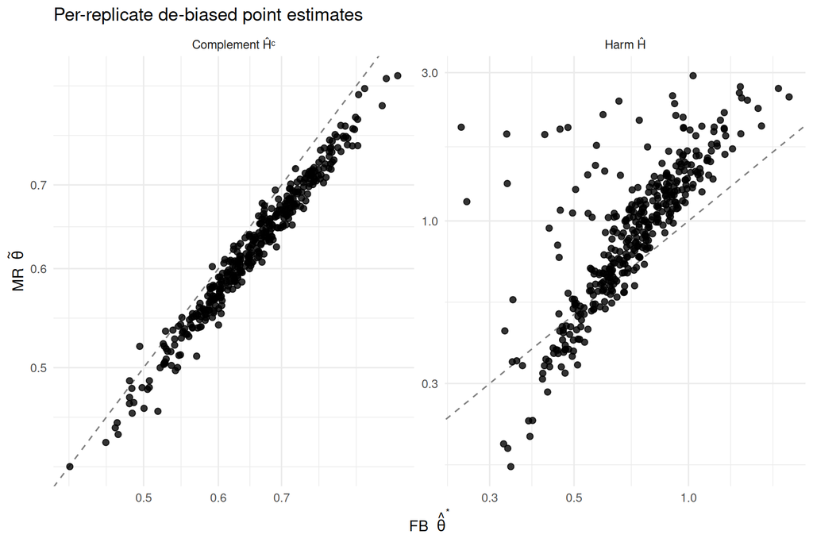

```r
if (run_smoke && !is.null(results)) {
  rd <- results[results$detected == 1, , drop = FALSE]

  # Per-block log-scale agreement (Tier-2 - Tier-1) on point estimate and bounds.
  agree_block <- function(suffix) {
    e1 <- rd[[paste0("t1_", suffix, "_est")]]; e2 <- rd[[paste0("t2_", suffix, "_est")]]
    l1 <- rd[[paste0("t1_", suffix, "_lo")]];  l2 <- rd[[paste0("t2_", suffix, "_lo")]]
    u1 <- rd[[paste0("t1_", suffix, "_hi")]];  u2 <- rd[[paste0("t2_", suffix, "_hi")]]
    ok <- is.finite(e1) & is.finite(e2)
    if (sum(ok) < 2L) return(NULL)
    dpt <- log(e2[ok]) - log(e1[ok])
    dlo <- log(l2[ok]) - log(l1[ok]); dhi <- log(u2[ok]) - log(u1[ok])
    list(
      tab = data.frame(
        Block = if (suffix == "H") "Harm \u0124" else "Complement \u0124\u1d9c",
        Quantity = c("log point", "log CI lower", "log CI upper"),
        mean_d = c(mean(dpt), .mfin(dlo), .mfin(dhi)),
        sd_d   = c(sd(dpt),   .sdfin(dlo), .sdfin(dhi)),
        stringsAsFactors = FALSE),
      n = sum(ok), corr = suppressWarnings(cor(log(e1[ok]), log(e2[ok]))),
      pts = data.frame(block = if (suffix == "H") "Harm \u0124" else "Complement \u0124\u1d9c",
                       t1 = e1[ok], t2 = e2[ok])
    )
  }

  aH <- agree_block("H"); aHc <- agree_block("Hc")
  parts <- Filter(Negate(is.null), list(aH, aHc))

  if (length(parts)) {
    tab <- do.call(rbind, lapply(parts, `[[`, "tab"))
    sub <- paste(vapply(parts, function(p)
      sprintf("%s: %d reps, corr %.3f", sub("  .*", "", p$tab$Block[1]), p$n, p$corr),
      character(1)), collapse = "  \u00b7  ")
    cat(as_raw_html(
      gt(tab, groupname_col = "Block") |>
        tab_header(title = "MR \u2212 FB (log scale)", subtitle = sub) |>
        cols_label(mean_d = "Mean \u0394", sd_d = "SD \u0394") |>
        fmt_number(columns = c(mean_d, sd_d), decimals = 4)
    ))

    pts <- do.call(rbind, lapply(parts, `[[`, "pts"))
    p <- ggplot(pts, aes(x = t1, y = t2)) +
      geom_abline(slope = 1, intercept = 0, linetype = 2, colour = "grey50") +
      geom_point(size = 2, alpha = 0.8) +
      scale_x_log10() + scale_y_log10() +
      facet_wrap(~ block, scales = "free") +
      labs(x = expression("FB  "*hat(theta)^"*"),
           y = expression("MR  "*tilde(theta)),
           title = "Per-replicate de-biased point estimates") +
      theme_minimal(base_size = 12)
    print(p)
  } else {
    cat("Too few paired replicates at smoke-test counts to draw the panel.\n")
  }
}
```

# 12 Notes for scale-up

```r
# Single, unambiguous start-to-finish wall-clock: from the first line of `setup`
# to here.  This is the true total cost of running the whole document -- setup +
# library loads + DGM build + every simulation replicate (Tier-2 gate AND Tier-1
# bootstrap) + all table rendering -- not a per-rep mean or a model.
.fmt_dur <- function(s) {
  h <- s %/% 3600; m <- (s %% 3600) %/% 60; sec <- round(s %% 60)
  if (h >= 1) sprintf("%d h %02d m %02d s", h, m, sec)
  else if (m >= 1) sprintf("%d m %02d s", m, sec)
  else sprintf("%.1f s", s)
}
.secs_total <- as.numeric(difftime(Sys.time(), .t0_doc, units = "secs"))
cat(sprintf("TOTAL wall-clock, start to finish: %s  (= %.0f s; %d reps on %d workers)\n",
            .fmt_dur(.secs_total), .secs_total, n_sims, n_workers))
```

```
TOTAL wall-clock, start to finish: 7.1 s  (= 7 s; 500 reps on 115 workers)
```